# R Tutorial: Introduction to R

Thursday, 12th March 2020

# Prerequisites

By this time, you should already have installed R and RStudio into your system. If you haven’t, install [R](https://cloud.r-project.org) and [RStudio](https://rstudio.com/products/rstudio/download/) using the link attached (just click the highlighted).

If you think your system doesn’t have the minimum computing power required or just don’t want to complicate yourself, don’t worry, RStudio also provide you with the cloud version (currently it’s in beta version). Visit this [link](https://login.rstudio.cloud/register) and follow the instructions (you need s decent internet connection for it to work well).

# Getting Familiar with the Interface

### Console

This is where you’ll input a command. The result of the command will also be displayed here.

### Environment and History

Track your object and variable list, show command history.

### Other Panels

Others include *Files*, *Plot*, *Packages*, *Help*, and *Viewer*.

**P.S.** *panel layout can be modified*.

[figure not shown]

# Getting Familiar with the Interface

Using only the console can be tedious, so use R script instead (serves the same purposes as do file in STATA). Personally, I prefer using R Notebook but this is a lesson for another time.

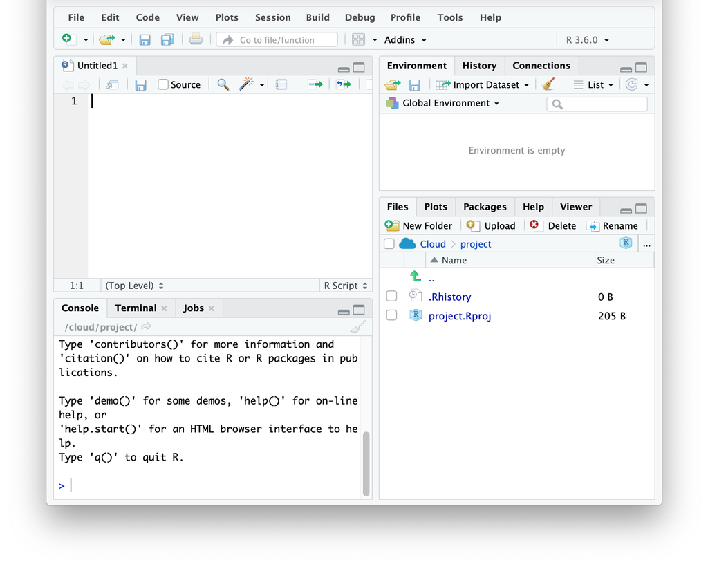

# Try it Yourself!

To display a character simply call the “`print()`” function.

```r
print("Hello World!")
```

```
## [1] "Hello World!"
```

# Try it Yourself!

R can also be used as a calculator. It’s able to calculate basic arithmetic such as addition…

```r
2 + 2
```

```
## [1] 4
```

subtraction…

```r
2 - 2
```

```
## [1] 0
```

multiplication…

```r
2 * 2
```

```
## [1] 4
```

division…

```r
2 / 2
```

```
## [1] 1
```

and also modulo operation.

```r
2 %% 2
```

```
## [1] 0
```

# Try it Yourself!

Result from a calculation can be combined with a sentence. Use the “`cat()`” function.

```r
cat("How many calories are there in a slice of chocolate pi? Approximately", 22 / 7, ".")
```

```
## How many calories are there in a slice of chocolate pi? Approximately 3.142857 .
```

# Data Types

Notice that character should be typed within “…”. Character is one of data types in R. Others include:

**1. Numeric**

```
## [1] 3.142857
```

**2. Integer**

```
## [1] 3
```

**3. Character (strings)**

```
## [1] "Hello World!"
```

**4. Logical (boolean)**

```
## [1] TRUE
```

```
## [1] FALSE
```

**5. Factor**

```
## [1] Male   Female
## Levels: Female Male
```

# Data Structures (Object)

Elements of those data types may be combined to form data structures. R can handle different data structures, each with its own features. But in this session, we’ll only cover vector.

1. Vector
2. Lists
3. Matrices
4. Arrays
5. Factors
6. Data Frames

To check data type/structure use the “`class()`” function.

```r
class(2020)
```

```
## [1] "numeric"
```

```r
class("2020")
```

```
## [1] "character"
```

# Creating Vector

Vector is the most basic way to structure your data. Creating a vector is easy. You only need to contain your data inside “`c()`”.

```r
c(1, 2, 3, 4)
```

```
## [1] 1 2 3 4
```

Notice that you need to call `c(1, 2, 3, 4)` each time you need it, which is impractical. So you need to assign that vector to a name using the “`<-`” operator. This vector will be stored inside your environment.

```r
vector1 <- c(1, 2, 3, 4)
```

To call it, just type its name.

```r
vector1
```

```
## [1] 1 2 3 4
```

The prominent features of a vector is that it can only store one type of data.

```r
(vector2 <- c(1, 2, "I'm a dreamer", 3))
```

```
## [1] "1"             "2"             "I'm a dreamer" "3"
```

```r
class(vector2)
```

```
## [1] "character"
```

# Accessing Vector Element

```r
length(c(1, 2, 3, 4, 5))
```

```
## [1] 5
```

```r
length(vector1)
```

```
## [1] 4
```

Each data inside a vector is indexed according to its position. In vector `c(5, 6, 7)`, `7` has an index of 3 (element position starts with 1). To access `7` in that vector, use the subset operator “`[]`” containing its element position or index. For example,

```r
c(5, 6, 7)[3]
```

```
## [1] 7
```

```r
vector1[3]
```

```
## [1] 3
```

# Manipulating Vector

Vector can be manipulated using basic arithmetic we learned before. For example,

```r
vector1
```

```
## [1] 1 2 3 4
```

```r
vector1 + 2
```

```
## [1] 3 4 5 6
```

This will add every elements inside `vector1` by `2`.

# Vector Operations

You can also use arithmetic operators between vectors. For example,

```r
(vector2 <- c(5:8))
```

```
## [1] 5 6 7 8
```

```r
vector1
```

```
## [1] 1 2 3 4
```

```r
vector2 + vector1
```

```
## [1]  6  8 10 12
```

This will add each element in `vector2` to its corresponding element in `vector1`.

# Comparing Vector

Does an element inside a vector has the same value as its corrersponding element inside another vector? You can easily check this using logical (boolean) operators.

```r
c(1, 2, 3) == c(1, 2, 3)
```

```
## [1] TRUE TRUE TRUE
```

Or is something greater than another…

```r
c(1, 2, 3) > c(0, 0, 0)
```

```
## [1] TRUE TRUE TRUE
```

less than antoher…

```r
c(1, 2, 3) < c(0, 0, 0)
```

```
## [1] FALSE FALSE FALSE
```

greater than or equal to…

```r
c(1, 2, 3) >= c(1, 2, 3)
```

```
## [1] TRUE TRUE TRUE
```

less than or equal to…

```r
c(1, 2, 3) <= c(1, 2, 3)
```

```
## [1] TRUE TRUE TRUE
```

not equal to…

```r
c(1, 2, 3, 4) != c(1, 2, 3, 4)
```

```
## [1] FALSE FALSE FALSE FALSE
```

**P.S.** *while “`==`” is used to compare two objects, “`=`” is only used to create an identity.*

# Introduction to Function: Computing Basic Statistics

Just as in mathematics, a function in R, indicated by “`...()`”, will provide you with an output as a function of input (argument). You have used several functions throughout this session.

Several other functions are useful, for example, to calculate descriptive statistics. Here, I have a vector called `vector3` containing numeric data from 50 to 100.

We can calculate its mean using…

```r
mean(vector3)
```

```
## [1] 75
```

standard deviation using…

```r
sd(vector3)
```

```
## [1] 14.86607
```

median using…

```r
median(vector3)
```

```
## [1] 75
```

variance using…

```r
var(vector3)
```

```
## [1] 221
```

If you forget how a function works, don’t be lazy to read the documentation using “`help()`” function or ask for help in the internet.

# Workflow: Setting the Working Directory

Unless specified, R looks for files that you ask it to load and put any files that you ask it to save in working directory. By default, working directory is usually located in your home directory. RStudio shows your current working directory at the top of the console. And you can print this out in R code by running the “`getwd()`” function.

```r
getwd()
```

```
## [1] "/Users/rinorsaduaneagusta/Desktop/Work/LAB-IE/Tutorial March 12th"
```

To see files contained inside working directory use the “`list.files()`” function.

```r
list.files()
```

```
##  [1] "console.png"                 "cover.png"
##  [3] "explore.png"                 "Introduction to R.Rmd"
##  [5] "Introduction-to-R.html"      "Introduction-to-R.pdf"
##  [7] "Introduction-to-R.Rmd"       "monthly_deaths.csv"
##  [9] "nobel.csv"                   "R Module 1.pptx"
## [11] "R Module 2.pptx"             "script.png"
## [13] "Untitled.R"                  "yearly_deaths_by_clinic.csv"
```

# Workflow: Setting the Working Directory

You can also set the working directory from within R using “`setwd()`” function. For example, here I want to change my working directory to Desktop

```r
setwd("/Users/rinorsaduaneagusta/Desktop/")
```

But there is another way to better organize your workflow: RStudio Project.

# Accessing External Packages

An R package is a collection of functions, data, and documentation that extends the capabilities of base R. To this date, there are more than 15,000 packages available at the Comprehensive R Archive Network (CRAN) and still counting!

A package can be installed using “`install.packages("package name)`” function. After successfully installing the package, we have to load it first so it can be used. This has to be done everytime you start a new project. To load a package, simply use “`library(package name)`” function.

Sometimes there will be a problem when loading the package, this is usually due to the incompatibility version of R and the package. Library function with no arguments prints a list of installed packages but you can check this easily inside the *Packages* panel.

# Working with Dataset

R has a bunch variety of built in datasets, we can access them through “`data()`” function. For example,

```r
data(mtcars)
```

This data will be available inside your environment. Or you can pass a “`package`” argument to load specific dataset from a package. For example,

```r
data(Cars93, package="MASS")
```

# Working with Dataset

You can also load an external dataset located inside your working directory. It can be in various formats such as tabular (xls, txt), using “`read.table("filename.format")`” function, or tab-delimited (csv), using

```r
df <- read.csv("nobel.csv")
```

(Don’t forget to assign a name or else all the data will be displayed in the console.)

R can also read a file directly from internet. Neat!

```r
df2 <- read.csv("http://ugm.id/tutorr")
```

… and many more!

**P.S.** *Few additional arguments that might be helpful*:

- `header = TRUE`
- `stringsAsFactor = FALSE`
- `skip = NA`
- `sep= ":"`